# Context-dependent consequences of including lagged effects in demographic models

Eric R. Scott<sup>1,✉</sup>, and Emilio M. Bruna<sup>1,2,3</sup>

19 July, 2023

<sup>1</sup> Department of Wildlife Ecology and Conservation, University of Florida, Gainesville, Florida 32611-0430  
<sup>2</sup> Center for Latin American Studies, University of Florida, Gainesville, Florida 32611-5530  
<sup>3</sup> Biological Dynamics of Forest Fragments Project, INPA-PDBFF, CP 478, Manaus, Amazonas 69011-970 Brazil

<sup>✉</sup> Correspondence: Eric R. Scott <scottericr@gmail.com>

Keywords: integral projection models; environmental stochasticity; lagged effects

Running title: Lagged Effects IPMs

# Abstract

# Introduction

1. Demographic models, such as IPMs and matrix models, are widely used for all kinds of stuff.
2. It has long been recognized that there is the potential for lagged effects. Including lagged effects in models has been a major technical challenge, but there are now multiple approaches for doing so. The studies assessing the potential for lagged effects on vital rates find that they indeed appear to be prevalent (Evers et al. 2021; Scott et al. 2022).
3. Lagged effects could be different in different habitat types (and this could be a big reason for differences between habitats)

# Methods

## IPMs

In preliminary investigation we found that the survival and growth of plants was better explained by treating seedlings and mature plants separately. Seedlings are physiologically different from small plants because they necessarily lack the underground reserves (of carbohydrates and meristems) that a small, mature plant may have. Therefore, we used general IPMs to model population dynamics with seedlings treated as a separate discreet class not structured by size. General IPMs allow for combinations of continuous and discrete states and transitions between them (Ellner et al. 2016).

$$n(z^{\prime},t+1) = R(z^\prime)n_s(t) + \int_L^U P(z^\prime,z) n(z,t)\;dz$$
{#eq:mature}

$$n_s(t+1) = \int_L^U F(z) n(z,t) \; dz$$
{#eq:sdlg}

$$R(z^\prime) = s_sG_s(z^\prime)$$
{#eq:R}

$$P(z^\prime, z) = s(z)G(z^\prime, z)$$
{#eq:P}

$$F(z) = p_f(z)f(z)g$$
{#eq:F}

Vital rate models for growth ($G_s(z^\prime)$ and $G(z^\prime, z)$) , survival ($s_s$ and $s(z)$), and flowering ($p_f(z)$) were fit using the long term demographic dataset. For established plants, these three vital rates were modeled as a smooth function of size in the previous census using generalized additive models (GAMs) fit with the `mgcv` package(Wood 2011) in R version 4.3.0 (2023-04-21) (R Core Team 2020) . For consistency, seedling survival and growth were also modeled using GAMs, but without size in the previous census as a predictor (i.e. intercept only models). For growth models ($G_s(z^\prime)$ and $G(z^\prime, z)$) a scaled t family distribution provided a better fit to the data than a gaussian fit as the residuals were leptokurtic with a simple gaussian model.

To build the general, density-independent, stochastic, kernel-resampled IPMs, we included environmental stochasticity in all vital rate models built using the long term demographic datset by adding a random effect of year (Figure 1). The random effect of year was included using a factor–smooth interaction which allowed the relationship between plant size and vital rates to vary in functional form among transition years. The kernel-resampling approach is to generate kernels corresponding to each transition year in the demographic dataset using the random smooths for year, and to iterate the IPM by drawing from these randomly. This is equivalent to the matrix selection approach for matrix population models described by Caswell (2001).

For the third method, we modeled the impacts of drought on vital rates explicitly and created general, density-independent, stochastic, parameter-resampled IPMs (*sensu* Metcalf et al. (2015)). We calculated the standardized precipitation evapotranspiraton index (SPEI) for our site using a published gridded dataset based on ground measurements (Xavier et al. 2016) as described in Scott et al. (2022). For all vital rate models fit using the long term demographic dataset, we modeled delayed effects of SPEI using distributed lag non-linear models with a maximum lag of 36 months(Scott et al. 2022) (Figure 1). To iterate these parameter-resampled IPMs, a random sequence of SPEI values was created by sampling years of the observed monthly SPEI data. Then, 36 month lags are calculated for each year starting in February (the month of the demographic census). These values are then used to predict fitted values from the vital rates models, generating different kernels at each iteration of the IPM. With this method, the kernels of successive iterations are not entirely independent because the SPEI values used in calculating vital rates include values used in the previous two iterations, but they are ergodic.

All IPMs were constructed and iterated using the `ipmr` package in R (Levin et al. 2021). The IPMs used 100 meshpoints and the midpoint rule for calculating kernels . For each type of IPM we iterated the model for 1000 time steps, discarding the first 100 time steps to omit transient effects. Stochastic growth rates ($\lambda_s$) were calculated as the average $ln(\lambda)$ from each time step (Caswell 2001) and back-transformed to be on the same scale as deterministic lambdas for comparison. We used the distribution of established plant sizes and proportion of seedlings from the full dataset as a starting population vector. While other starting population vectors were possible, the choice is of little importance as it will only impact transient dynamics, which we aren’t interested in for this study.

To estimate uncertainty around the per-capita growth rates (lambdas), we created 500 bootstraps of the demographic dataset by sampling individual plants with replacement within each habitat. For each bootstrap, we then re-fit vital rates models (all except germination and establishment rate, fruits per flowering plant, and seeds per fruit, which were estimated using different datasets), constructed IPMs, and calculated a value for lambda as described above. We then used these bootstraped estimates of lambda to calculate bias corrected 95% confidence intervals (Ellner et al. 2016).

This workflow was managed using the `targets` R package (Landau 2021) which also allowed us to track computational time spent on each IPM for comparison.

# Results

Population growth rates were consistently higher in continuous forest compared to forest fragments across IPM types (Table 2).

The time to iterate the DLNM models is much higher than than deterministic and kernel-resampled. The greater use of computational resources is likely a result of `predict()` being much slower for GAMs with 2D smooths because the number of knots is much higher compared to the GAMs used for the vital rates models in the determinsitic and kernel-resampled IPMs.

```
#> # A tibble: 3 × 2
#>   IPM   mean_time_min
#>   <chr>         <dbl>
#> 1 det            0.02
#> 2 dlnm          87.1
#> 3 stoch          0.07
```

Figure 2 has some interesting things in it:

- for the deterministic IPM (and the kernel-resampled IPM?) there are slightly more of the smallest plants and the largest plants in CF compared to FF (i.e. more medium sized plants in FF).
- For the kernel-resampled IPM (random effect of year), the fluctuations are extremely similar between CF and FF
- For the parameter-resampled IPM (DLNM) the size structure of the population is a LOT more variable in FF. This makes sense as we know lagged effects are more important in fragments.
- Also, the fluctuations in size structure in CF do not match the fluctuations in FF as well (can see this by the increased spread of points in Figure 2B)
- Also, in the parameter-resampled IPM (and only in this one), we see a shift toward smaller plants in FF compared to CF

# Discussion

- Our finding that the choice of IPM didn’t change the relative ranking of CF and FF is consistent with Kaye and Pyke (2003) finding that method effected stochastic lambda, but relative ranking of populations was consistent.

# Acknowledgments

# CRediT Statement

ERS contributed to the conceptualization, methodology, formal analysis, and led the writing of the original draft. EMB contributed to the conceptualization, methodology, and writing and also acquired funding.

# Data Availability Statement

# Tables

Table 1: Comparison of vital rate models used to build IPM. The ‘Effect of Environment’ column describes how environmental effects were included in models. Those with ‘none’ were used to build deterministic IPMs; those with a random effect of year were used to build stochastic, kernel-resampled IPMs; and those with a distributed lag non-linear model (DLNM) were used to build stochastic, parameter-resampled IPMs. ‘edf’ is the estimated degrees of freedom of the penalized GAM. ΔAIC is calculated within each habitat and vital rate combination. ΔAIC within 2 indicates models are equivalent.

| Habitat | Vital Rate | Effect of Environment | edf | ΔAIC |
| --- | --- | --- | --- | --- |
| CF | Survival | Random effect of year | 43.26 | 0 |
| CF | Survival | DLNM | 19.72 | 78.92 |
| CF | Survival | None | 4.976 | 260 |
| CF | Growth | Random effect of year | 78.43 | 0 |
| CF | Growth | DLNM | 23.87 | 158.5 |
| CF | Growth | None | 7.81 | 1896 |
| CF | Flowering | DLNM | 19.59 | 0 |
| CF | Flowering | Random effect of year | 17.19 | 1.627 |
| CF | Flowering | None | 7.468 | 381.9 |
| CF | Seedling survival | None | 1 | 0 |
| CF | Seedling survival | Random effect of year | 1.817 | 1.386 |
| CF | Seedling survival | DLNM | 4.008 | 1.528 |
| CF | Seedling growth | Random effect of year | 9.475 | 0 |
| CF | Seedling growth | DLNM | 8.952 | 2.902 |
| CF | Seedling growth | None | 1 | 172.3 |
| FF | Survival | DLNM | 14.95 | 0 |
| FF | Survival | Random effect of year | 19.21 | 35.68 |
| FF | Survival | None | 4.333 | 51.25 |
| FF | Growth | DLNM | 25.18 | 0 |
| FF | Growth | Random effect of year | 37.84 | 200 |
| FF | Growth | None | 5.599 | 382.8 |
| FF | Flowering | DLNM | 20.61 | 0 |
| FF | Flowering | Random effect of year | 13.81 | 27.4 |
| FF | Flowering | None | 5.007 | 101.7 |
| FF | Seedling survival | DLNM | 5.574 | 0 |
| FF | Seedling survival | Random effect of year | 5.088 | 5.721 |
| FF | Seedling survival | None | 1 | 6.491 |
| FF | Seedling growth | Random effect of year | 6.25 | 0 |
| FF | Seedling growth | DLNM | 8.182 | 2.29 |
| FF | Seedling growth | None | 1 | 5.745 |

Table 2: Population growth rates for continuous forest (CF) and forest fragments (FF) under different kinds of IPMs with bootstrapped, bias-corrected, 95% confidence intervals.

| IPM | Habitat | $\lambda$ |
| --- | --- | --- |
| Deterministic | FF | 0.9778 (0.9736, 0.9823) |
| Deterministic | CF | 0.9897 (0.9877, 0.9920) |
| Stochastic, kernel-resampled | FF | 0.9787 (0.9735, 0.9835) |
| Stochastic, kernel-resampled | CF | 0.9913 (0.9892, 0.9939) |
| dlnm | FF | 0.9595 (0.9459, 0.9689) |
| dlnm | CF | 0.9795 (0.9752, 0.9867) |

# Figures

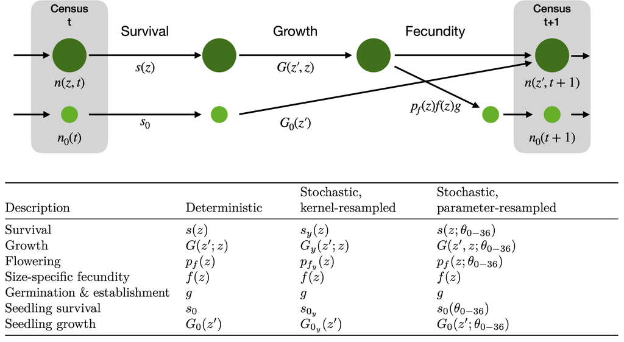

Figure 1: Lifecycle diagram of *Heliconia acuminata*. Each transition is associated with an equation for a vital rate function. The functions shown on the diagram correspond to those used to construct a general, density-independent, deterministic IPM. The table below shows the equivalent equations for stochastic, kernel-resampled IPMs and stochastic, parameter-resampled IPMs.

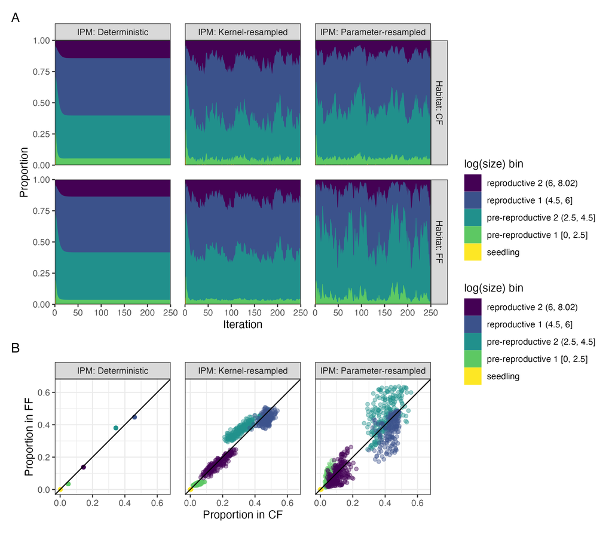

Figure 2: Relative proportions of plant sizes in the first 250 iterations of the IPM simulations. Stacked area charts (A) show the relative size/stage distribution of plants in continuous forest (CF, top row) and forest fragments (FF, bottom row) in each of the three IPMs (columns). The proportion of each size class in CF and FF for each iteration is shown in B with the first 30 iterations removed to not include transient dynamics. A 1:1 line is plotted in black. Size categories include seedlings (a discrete category in the IPMs), pre-reproductive 1 (log(size) 0–2.5) that have low average survival (< 0.9) and a near 0 probability of flowering, pre-reproductive 2 (log(size) 2.5–4.5) that have a higher average survival probabilty (> 0.8) and a near 0 probability of flowering, reproductive 1 (log(size) 4.5–6) that have a high average survival probability (>0.95) and a lower flowering probability (< 0.25), and reproductive 2 (log(size) 6+) that have a high average survival probability (>0.95) and higher flowering proability (> 0.2).

# References

Caswell, H. 2001. Matrix population models: Construction, analysis, and interpretation. Sinauer Associates, Sunderland.

Ellner, S. P., D. Z. Childs, and M. Rees. 2016. Data-driven modelling of structured populations: A practical guide to the integral projection model. Springer Science+Business Media, New York, NY.

Evers, S. M., T. M. Knight, D. W. Inouye, T. E. X. Miller, R. Salguero-Gómez, A. M. Iler, and A. Compagnoni. 2021. [Lagged and dormant season climate better predict plant vital rates than climate during the growing season](https://doi.org/10.1111/gcb.15519). Global Change Biology 27:1927–1941.

Kaye, T. N., and D. A. Pyke. 2003. The effect of stochastic technique on estimates of population viability from transition matrix models. Ecology 84:1464–1476.

Landau, W. M. 2021. [The targets r package: A dynamic make-like function-oriented pipeline toolkit for reproducibility and high-performance computing](https://doi.org/10.21105/joss.02959) 6:2959.

Levin, S. C., D. Z. Childs, A. Compagnoni, S. Evers, T. M. Knight, and R. Salguero-Gómez. 2021. [Ipmr: Flexible implementation of Integral Projection Models in R](https://doi.org/10.1111/2041-210X.13683). Methods in Ecology and Evolution 12:1826–1834.

Metcalf, C. J. E., S. P. Ellner, D. Z. Childs, R. Salguero-Gómez, C. Merow, S. M. McMahon, E. Jongejans, et al. 2015. [Statistical modelling of annual variation for inference on stochastic population dynamics using Integral Projection Models](https://doi.org/10.1111/2041-210X.12405). Methods in Ecology and Evolution 6:1007–1017.

R Core Team. 2020. *R: A language and environment for statistical computing*. Vienna, Austria.

Scott, E. R., M. Uriarte, and E. M. Bruna. 2022. [Delayed effects of climate on vital rates lead to demographic divergence in Amazonian forest fragments](https://doi.org/10.1111/gcb.15900). Global Change Biology 28:463–479.

Wood, S. N. 2011. Fast stable restricted maximum likelihood and marginal likelihood estimation of semiparametric generalized linear models 73:3–36.

Xavier, A. C., C. W. King, and B. R. Scanlon. 2016. [Daily gridded meteorological variables in Brazil (1980)](https://doi.org/10.1002/joc.4518). International Journal of Climatology 36:2644–2659.